# Steam Games Analysis

Author

Howard Song, Milan Bertolutti, Yuanchen Ling, Maryamalsadat Hosseini

# Summary

This project investigates how well game characteristics can predict the total number of reviews received by Steam games released between 2018 and 2022. Using the Steam Games Dataset, we explore relationships between review counts and game features, including price, genres, categories, number of supported languages, and release date. We conduct exploratory data analysis to examine review distributions and feature relationships, followed by regression modeling to evaluate predictive performance. The results show that our linear regression model explains approximately one-third of the variation in log review counts on the test set and performs better than the mean baseline in cross-validation. These findings suggest that game characteristics provide useful predictive information and may help developers and publishers better understand patterns in review activity. However, the model is less accurate for games with very few or very high review counts, and other factors, such as marketing activities, developer reputation, and community engagement, are not included in the model.

# Introduction

The video game industry has become a major part of the digital entertainment market, with online platforms such as Steam providing developers and publishers access to a global audience. In addition to purchasing and playing games, Steam users can share their experiences and recommend games through reviews (Valve, n.d.). These reviews provide insights into player opinions and serve as a measurable indicator of audience engagement.

Understanding the factors associated with review volume is important for game developers and publishers because reviews can provide insights into player engagement and a game’s visibility among potential players. Previous research has examined the relationship between online reviews and video game usage (Philp & Nepomuceno, 2024), as well as how different player engagement modes influence review characteristics (Guzsvinecz & Szűcs, 2026). Research on the Steam platform has also investigated game reviews and their relationship with game characteristics (Lin et al., 2019). These studies provide relevant background for understanding review activity in video games. However, examining how selected game characteristics can be used to predict the total number of reviews remains the focus of our study. Characteristics such as price, genres, available features, language support, and release timing may be associated with differences in the number of reviews received. Examining these relationships may help developers and publishers better understand which game characteristics are associated with greater audience engagement.

This study investigates the following research question: How well can selected game characteristics predict the total number of reviews received by Steam games released between 2018 and 2022? Specifically, the analysis examines five groups of explanatory variables: game price, number of supported languages, release date, genres, and Steam categories. Total review count, calculated by adding positive and negative reviews, is used as the response variable.

The analysis uses the Steam Games Dataset published by FronkonGames on Hugging Face (FronkonGames, n.d.). Each row represents an individual Steam game, with information including release date, price, genres, categories, language support, and positive and negative review counts. The study focuses on 46,859 games released between 2018 and 2022. The dataset is randomly divided into training and test sets, with 80% of the data used for exploratory data analysis and model development and the remaining 20% reserved for final model evaluation.

To investigate the research question, we first conduct exploratory data analysis to examine the distribution of review counts and explore their associations with selected game characteristics. We then develop a linear regression model to predict the logarithm of total review counts and compare its performance with a baseline model that predicts the mean. Model performance is evaluated using five-fold cross-validation on the training set and a held-out test set.

This study aims to evaluate the predictive value of selected game characteristics rather than establish causal relationships. By examining both feature associations and predictive performance, the analysis provides insights into how well game metadata can explain and predict differences in review volume, while highlighting the limitations of using these characteristics alone to estimate player engagement.

# Methods

## Data

The code below downloads the Steam Games Dataset (FronkonGames, n.d.) from Hugging Face and saves an unmodified copy to `data/raw/`. The download is skipped if that file already exists. We then keep games released between 2018 and 2022, drop rows with missing review counts, duplicate games or unreadable release dates, and save the cleaned data to `data/processed/`. This leaves 46,859 games, which we split at random into a training set (80%) and a test set (20%) using seed 1234. The split happens before any exploratory analysis: only the training set is used for exploration and model building, and the test set is used once, at the end, to report final performance.

```python
import sys
from pathlib import Path

import pandas as pd
from sklearn.model_selection import train_test_split

# Reuse the download and cleaning functions from scripts/process_data.py
sys.path.append("../scripts")
from process_data import (
    DATA_URL,
    EXPECTED_COHORT_SIZE,
    RAW_FILENAME,
    SEED,
    TEST_SIZE,
    clean_data,
    download_data,
)

raw_dir = Path("../data/raw")
processed_dir = Path("../data/processed")
processed_dir.mkdir(parents=True, exist_ok=True)

# 1. Download the raw data (skipped if it is already in data/raw/)
raw_path = download_data(DATA_URL, raw_dir / RAW_FILENAME)
raw = pd.read_parquet(raw_path)

# 2. Clean it and record every dropped row with the reason
cleaned, ledger = clean_data(raw)
if len(cleaned) != EXPECTED_COHORT_SIZE:
    raise ValueError(
        f"Expected {EXPECTED_COHORT_SIZE:,} games after cleaning, got {len(cleaned):,}."
    )

# 3. Split before any exploration
train_split, test_split = train_test_split(
    cleaned, test_size=TEST_SIZE, random_state=SEED
)

cleaned.to_csv(processed_dir / "cleaned.csv", index=False)
ledger.to_csv(processed_dir / "drop-ledger.csv", index=False)
train_split.to_csv(processed_dir / "train.csv", index=False)
test_split.to_csv(processed_dir / "test.csv", index=False)

ledger["reason"].value_counts()
```

```
Downloading https://huggingface.co/datasets/FronkonGames/steam-games-dataset/resolve/6c21457b9ebf0a6a7f5b91e11281d65d456ea30e/data/train-00000-of-00001.parquet
  -> ../data/raw/steam_games.parquet
```

```
reason
released outside 2018-2022    77287
Name: count, dtype: int64
```

```python
train = pd.read_csv(processed_dir / "train.csv")
train.shape
```

```
(37487, 9)
```

## Target variable

We predict `log1p(total_reviews)`, the log of reviews + 1. Logarithmically transforming prevents the few very popular games from dominating the model. Adding 1 to the value keeps games with zero reviews defined.

```python
import numpy as np

X_train = train.drop(columns=["total_reviews"])
y_train = np.log1p(train["total_reviews"])
```

## Features

We used five groups of features, all built from the training data:

- **Price** in USD, used as is.
- **Number of supported languages**, capped at 10, since adding languages beyond that point makes little further difference.
- **Release day**: days since 1 January 2018, so the model can pick up trends over the 2018–2022 period.
- **Genres** and **categories**: one yes/no column per genre and per Steam category. Only levels that appear in at least 1% of training games are kept, so rare labels do not add noise. `Steam Trading Cards` is excluded because Valve grants it to games that already sell well, making it a consequence of popularity rather than a cause.

`appID` and `name` are identifiers and are not used as features.

### Transformation

```python
# Transform the data to fit contract. Clip number of languages to a max of 10, and calculate release day.
X_train["n_languages"] = X_train["n_languages"].clip(upper=10)
X_train["release_day"] = (pd.to_datetime(X_train["release_date"]) - pd.Timestamp("2018-01-01")).dt.days
```

### Preprocessing

```python
from sklearn.compose import ColumnTransformer
from sklearn.feature_extraction.text import CountVectorizer
from sklearn.preprocessing import StandardScaler

list_encoder = CountVectorizer(
    token_pattern=r'"([^"]+)"', # This keeps multi word labels
    lowercase=False,
    binary=True,
    min_df=0.01,
    stop_words=["Steam Trading Cards"],
)

preprocessor = ColumnTransformer([
    ("numeric", StandardScaler(), ["price", "n_languages", "release_day"]),
    ("genre", list_encoder, "genres"),
    ("category", list_encoder, "categories"),
])
```

## Model and evaluation

We fit a linear regression, with the preprocessing and model combined in one pipeline. We compare it to a baseline that always predicts the mean.

Both models are scored with 5-fold cross-validation on the training set. Because preprocessing is inside the pipeline, it is re-fit on each fold, so the validation data never influences it.

Our main metric is Root Mean Square Error (RMSE) on the `log1p` scale, which measures relative error so that a few very popular games do not dominate. We also report Mean Absolute Error (MAE) and R².

```python
from sklearn.dummy import DummyRegressor
from sklearn.linear_model import LinearRegression
from sklearn.model_selection import cross_validate
from sklearn.pipeline import make_pipeline

pipe = make_pipeline(preprocessor, LinearRegression())

models = {
    "Baseline (mean)": DummyRegressor(),
    "Linear regression": pipe,
}

scoring = {
    "RMSE": "neg_root_mean_squared_error",
    "MAE": "neg_mean_absolute_error",
    "R²": "r2",
}

cv_results = {}
for name, model in models.items():
    scores = cross_validate(model, X_train, y_train, cv=5, scoring=scoring)
    cv_results[name] = {
        "RMSE": -scores["test_RMSE"].mean(),
        "MAE": -scores["test_MAE"].mean(),
        "R²": scores["test_R²"].mean(),
    }

cv_results = pd.DataFrame(cv_results).T.round(3)
```

# Results

## Exploratory Data Analysis

### Summary Statistics

The training dataset contains 37,487 Steam games. Descriptive statistics for the numerical variables are presented in Table 1.

Table 1: Descriptive statistics of the training dataset

| Variable | N | Mean | SD | Min | Q1 | Median | Q3 | Max |
| --- | --- | --- | --- | --- | --- | --- | --- | --- |
| Price (USD) | 37487 | 4.58 | 12.60 | 0.0 | 0.59 | 1.99 | 4.99 | 999.0 |
| Supported languages (count) | 37487 | 4.54 | 11.68 | 0.0 | 1.00 | 1.00 | 3.00 | 103.0 |
| Total reviews (count) | 37487 | 1158.54 | 17109.06 | 0.0 | 2.00 | 14.00 | 61.00 | 1227784.0 |

The mean number of reviews (1,158.54) is substantially higher than the median (14), indicating a strongly right-skewed distribution. This motivates the log transformation used in the exploratory visualization.

The exploratory data analysis was conducted using only the training dataset to avoid data leakage.

### Distribution of Total Reviews

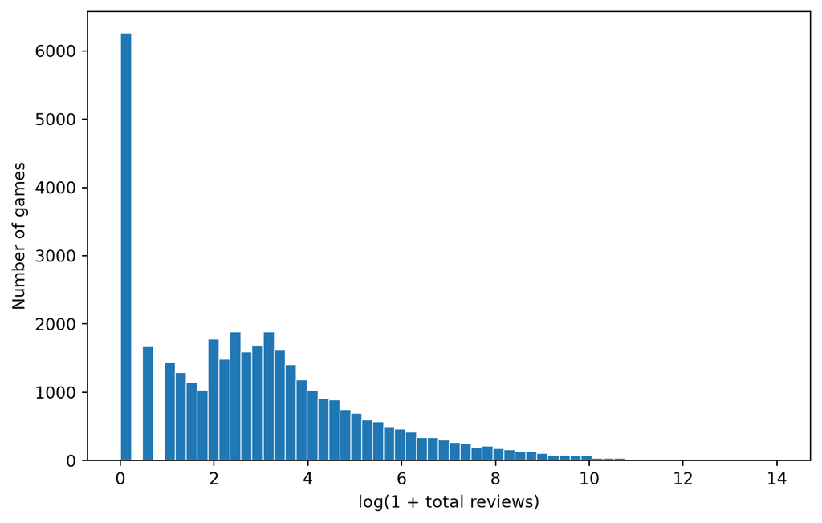

Figure 1: Distribution of log-transformed total reviews among Steam games in the training dataset. The log(1 + total reviews) transformation accounts for games with zero reviews and reduces the influence of extreme values.

The distribution of total reviews is highly right-skewed (Figure 1). Most games receive relatively few reviews, while a small number of games receive substantially more. Applying the log transformation makes the distribution easier to visualize while retaining games with zero reviews.

### Supported Languages and Review Counts

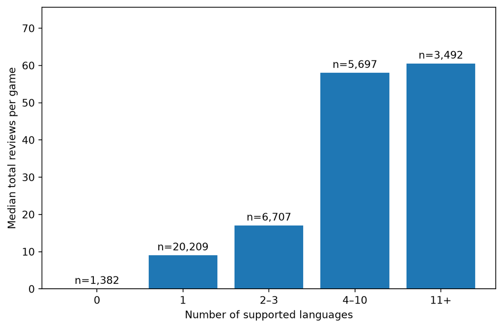

Figure 2: Median total reviews by the number of supported languages. The sample size of each group is displayed above the corresponding bar.

Games supporting more languages tend to have higher median review counts (Figure 2). This suggests a positive association between language availability and review volume. However, this relationship is descriptive and does not establish causality.

## Model performance

After cross-validation, we fit the linear regression on the full training set and scored it once on the test set.

```python
from sklearn.metrics import root_mean_squared_error, mean_absolute_error, r2_score

pipe.fit(X_train, y_train)

# Read and transform test data in same way as training data was
test = pd.read_csv("../data/processed/test.csv")
X_test = test.drop(columns=["total_reviews"])
y_test = np.log1p(test["total_reviews"])
X_test["n_languages"] = X_test["n_languages"].clip(upper=10)
X_test["release_day"] = (pd.to_datetime(X_test["release_date"]) - pd.Timestamp("2018-01-01")).dt.days

y_pred = pipe.predict(X_test)

test_results = pd.DataFrame({
    "RMSE": [root_mean_squared_error(y_test, y_pred)],
    "MAE": [mean_absolute_error(y_test, y_pred)],
    "R²": [r2_score(y_test, y_pred)],
}, index=["Linear regression"]).round(3)

# Numbers quoted in the text below
cv_base = cv_results.loc["Baseline (mean)"]
cv_lr = cv_results.loc["Linear regression"]
test_lr = test_results.loc["Linear regression"]
error_factor = np.exp(test_lr["MAE"])  # MAE on the log scale -> multiplicative error
```

```python
pd.concat(
    {"Cross-validation": cv_results, "Test set": test_results},
    names=["Evaluated on", "Model"],
) + 0.0  # turns the baseline's rounded R² of -0.000 into 0.000
```

Table 2: Cross-validation and test-set performance of the baseline and linear regression models

| Evaluated on | Model | RMSE | MAE | R² |
| --- | --- | --- | --- | --- |
| Cross-validation | Baseline (mean) | 2.289 | 1.778 | 0.000 |
|  | Linear regression | 1.846 | 1.436 | 0.349 |
| Test set | Linear regression | 1.829 | 1.417 | 0.340 |

Linear regression beats the mean baseline on every metric (Table 2). In cross-validation it lowers RMSE from 2.29 to 1.85 and explains 35% of the variance in log reviews, while the baseline explains none. The improvements are there but the model only explains some of the variance. The features Price, number of languages, release day, genres and categories together account for about a third of the variation in how many reviews a game gets. This indicates that there are features out there that explain more of that variance that was not trained in the model.

The gap between the training validation is very close together (RMSE 1.83 vs 1.85; R² 0.34 vs 0.35). This means the model is not overfitting and should perform about as well on other Steam games released in 2018 - 2022. In practical terms, the test MAE is 1.42 on the log scale. Because the model predicts $\log(1 + y)$, a gap of $d$ between the actual count $y$ and the predicted count $\hat{y}$ on the log scale is a ratio of $e^{d}$ on the original scale:

$$\log(1 + y) - \log(1 + \hat{y}) = d
\quad \Longleftrightarrow \quad
\frac{1 + y}{1 + \hat{y}} = e^{d}$$

Setting $d$ to the MAE gives $e^{\text{MAE}} \approx$ 4.1, so a typical prediction is off by a factor of about 4.1 in either direction. For example, a game predicted to receive 100 reviews would typically end up with somewhere between 24 and 412.

## Prediction accuracy by game popularity

### Visualization Code:

```python
import altair as alt

# > Citation Claude Opus 5.5 was used for this visualization

# Group test games by their actual number of reviews.
# Groups are about half a power of ten wide, so they are evenly spaced on a log scale.
edges = [-1, 0, 3, 10, 30, 100, 300, 1000, 3000, np.inf]
review_group = pd.cut(
    test["total_reviews"],
    bins=edges,
    labels=["0", "1–3", "4–10", "11–30", "31–100", "101–300", "301–1,000", "1,001–3,000", "3,001+"],
)

predictions = pd.DataFrame({
    "group": review_group,
    "actual": test["total_reviews"],
    "predicted": np.expm1(y_pred),  # back to review counts
})

group_summary = predictions.groupby("group", observed=True).agg(
    games=("actual", "size"),
    actual=("actual", "median"),
    predicted=("predicted", "median"),
    predicted_low=("predicted", lambda p: p.quantile(0.25)),
    predicted_high=("predicted", lambda p: p.quantile(0.75)),
)

# Numbers quoted in the text below
lowest = group_summary.iloc[0]
highest = group_summary.iloc[-1]

#| code-fold: true
alt.data_transformers.disable_max_rows()  # plot every test game (Altair's default limit is 5,000 rows)

# One shared scale for every review axis, so the two panels line up.
# symlog's default ticks bunch at the top, so place them at powers of ten.
max_reviews = predictions[["actual", "predicted"]].max().max()
scale = alt.Scale(type="symlog", domain=[0, max_reviews])
axis = alt.Axis(values=[0, 1, 10, 100, 1_000, 10_000, 100_000, 1_000_000],
                labelExpr="format(datum.value, ',')")

# (A) Every game, with the perfect-prediction line and the group boundaries
scatter = alt.Chart(predictions[["actual", "predicted"]]).mark_circle(
    size=8, opacity=0.15, color="#1f77b4"
).encode(
    x=alt.X("actual", scale=scale, axis=axis, title="Actual reviews"),
    y=alt.Y("predicted", scale=scale, axis=axis, title="Predicted reviews"),
)
perfect = alt.Chart(pd.DataFrame({"reviews": [0, max_reviews]})).mark_line(
    color="black", strokeDash=[4, 4]
).encode(
    x=alt.X("reviews", scale=scale),
    y=alt.Y("reviews", scale=scale),
)
boundaries = alt.Chart(pd.DataFrame({"edge": [e + 0.5 for e in edges[1:-1]]})).mark_rule(
    color="grey", opacity=0.4
).encode(x=alt.X("edge", scale=scale))

panel_a = (boundaries + scatter + perfect).properties(
    width=300, height=300, title="A. Every test game"
)

# (B) Group medians, with the middle 50% of predictions
summary = group_summary.reset_index()
summary["group"] = summary["group"].astype(str)
medians = summary.melt(
    id_vars=["group", "games"], value_vars=["actual", "predicted"],
    var_name="type", value_name="reviews",
)
medians["type"] = medians["type"].str.capitalize()

x_group = alt.X("group", sort=None, title="Actual reviews (grouped)", axis=alt.Axis(labelAngle=-45))
spread = alt.Chart(summary).mark_rule(strokeWidth=3, opacity=0.4, color="#1f77b4").encode(
    x=x_group,
    y=alt.Y("predicted_low", scale=scale, axis=axis, title="Number of reviews"),
    y2="predicted_high",
)
dots = alt.Chart(medians).mark_point(filled=True, size=60, opacity=1).encode(
    x=x_group,
    y=alt.Y("reviews", scale=scale, axis=axis),
    color=alt.Color("type", title=None,
                    scale=alt.Scale(domain=["Actual", "Predicted"], range=["black", "#1f77b4"])),
    tooltip=[
        "group", "type",
        alt.Tooltip("reviews", format=",.0f", title="Median reviews"),
        alt.Tooltip("games", format=",", title="Games in group"),
    ],
)

panel_b = (spread + dots).properties(width=300, height=300, title="B. Grouped by actual reviews")

fig_groups = (panel_a | panel_b).resolve_scale(y="shared")
```

```python
fig_groups
```

[interactive chart not shown]

Figure 3: Predicted versus actual review counts for test-set games. (A) Every test game, with the dashed line marking perfect prediction and grey lines marking group boundaries. (B) Median actual and predicted review counts within each group of actual reviews; vertical bars show the middle 50% of predictions.

Figure 3 compares predicted and actual review counts for the 9,372 test games in two ways. Panel A plots every game. If the model were perfect, every point would sit on the dashed line. The cloud is clearly flatter than the line, but it is hard to read beyond that. With this many games the points overlap heavily. Review counts are also whole numbers, so games with few reviews pile up in vertical stripes at 0, 1, 2 and so on. From panel A alone it is hard to tell where most games lie or what a typical prediction looks like at a given level of popularity.

Panel B summarises the same games. It splits them into nine groups by actual review count (the grey lines in panel A) and shows the median actual and median predicted count in each group, along with the middle 50% of predictions. Grouping has three advantages here:

- **No overplotting.** Each group is reduced to a few marks, so nothing is hidden behind other points.
- **Equal weight for small groups.** The few hundred very popular games get as much space as the thousands of small ones, instead of being lost in a corner of the cloud.
- **Robust summaries.** Medians are not pulled around by a handful of extreme games, and each group still holds between 285 and 1,945 games, so the medians are stable.

Panel B shows that the model’s predictions are pulled toward the middle. Across the nine groups the median actual review count ranges from 0 to 8,261, but the median prediction only ranges from 6 to 226. As a result the model over-predicts games with few or no reviews and under-predicts popular ones. Games with more than 3,000 reviews are predicted to get about 37 times fewer reviews than they actually received.

This pattern is expected from a model that explains only about a third of the variance. Price, languages, genres and categories can separate a polished game from a bare-bones one, but they cannot tell a hit from an ordinary well-made game. The factors behind a breakout hit, such as marketing, quality and word of mouth, are not in the data. The model is therefore more useful for comparing games roughly than for predicting the review count of any single game, especially a very popular one.

# Discussion

## Summary of Findings and Link to Research Question

This study examined how well selected game characteristics predict the total number of reviews received by Steam games released between 2018 and 2022. The results show that these features provide useful predictive information, but explain only part of the differences in review counts, accounting for approximately 34% of the variation in log review counts on the test set (R² = 0.340). Although the linear regression model performed better than the mean baseline in cross-validation, its predictions were less accurate for games with very few or very high review counts.

## Real-world implications

These findings suggest that game characteristics available on Steam provide some useful information about review volume. Developers and publishers may use these characteristics to compare games with different features and understand general patterns in review activity. However, the model should not be used to make precise predictions for individual games. Review volume is also not a direct measure of game quality, player satisfaction, or commercial success. Other factors, such as marketing activities, community engagement, and external visibility, may also influence review counts.

## Alignment with Expectations

Some findings matched our expectations, including the strong right-skew in review counts (mean = 1,158.54; median = 14) and higher median review counts for games supporting more languages. The model also showed a clear tendency to overpredict review counts for games with few or no reviews and underpredict them for games with more than 3,000 reviews.

## Assumptions and Limitations

Our model struggles at both ends of the distribution of review counts. A large portion of games in the training set have no reviews, and a linear model using log1p(total_reviews) treats these as low values rather than as a separate group. Therefore, it does not explicitly model zero-review games. As shown in Panel B of Figure 3, predictions are pulled toward the middle: the model overpredicts review counts for games with few or no reviews and underpredicts them for games with the highest review counts. A model designed to account for excess zero counts may help address this limitation. Linear regression assumes that the relationships between the selected features and log review counts can be represented by a linear combination. It may therefore miss nonlinear relationships and interactions. The model also uses only five groups of game characteristics and excludes potentially important factors such as marketing activities, developer reputation, and community size. In addition, games released in different years may have had different amounts of time to accumulate reviews, affecting comparisons. Finally, these results describe predictive relationships and do not establish that any particular game characteristic causes an increase in reviews.

## Potential Impact

These insights may help developers and publishers make more informed decisions about game design and marketing by providing a general understanding of the characteristics associated with review volume. However, review counts should be considered alongside other indicators of game performance.

## Future directions

Future research could examine whether adding factors such as game ratings, marketing activities, developer reputation, and community size improves prediction performance. It could also investigate whether relationships between game characteristics and review counts differ across release years. Comparing linear regression with nonlinear, zero-inflated, or two-part models may help address the prediction errors observed in this study. Finally, applying similar methods to games from other release periods or platforms could help assess whether these findings generalize beyond the dataset.

# References

FronkonGames. (n.d.). Steam Games Dataset [Data set]. Hugging Face. https://doi.org/10.57967/hf/0511

Guzsvinecz, T., & Szűcs, J. (2026). Emotions in play: A length and sentiment analysis of Steam reviews by player engagement mode. Heliyon, 12, e45258. https://doi.org/10.1016/j.heliyon.2026.e45258

Lin, D., Bezemer, C. P., Zou, Y., & Hassan, A. E. (2019). An empirical study of game reviews on the Steam platform. Empirical Software Engineering, 24, 170–207. https://doi.org/10.1007/s10664-018-9627-4

Philp, M., & Nepomuceno, M. V. (2024). How reviews influence product usage post-purchase: An examination of video game playtime. Journal of Business Research, 172, 114456. https://doi.org/10.1016/j.jbusres.2023.114456

Valve. (n.d.). User reviews. Steamworks Documentation. https://partner.steamgames.com/doc/store/reviews